# Reflection Analytics

Time Period: **Week 1 (Jan 8 - 12)**

This notebook is based on the csv extracted from Quercus from individual "Reflections" pages, by clicking on the "Student Analysis" tab. All student personal data has been removed, and the notebook only deals with aggregated groups (i.e. lecture assigned, engineering discipline).

## Summary of Analysis

```python
# define imports
import pandas as pd
import numpy as np

from matplotlib import pyplot as plt
import seaborn as sns
import plotly

from wordcloud import WordCloud
from wordcloud import ImageColorGenerator
from wordcloud import STOPWORDS

import warnings
warnings.filterwarnings('ignore')

plt.style.use('fivethirtyeight')
```

```python
# read student data
student_data_path = "../class_data/ClassList-20241-APS106H1-S.csv" # changed file to csv, was getting erros on excel
students_df = pd.read_csv(student_data_path)

# read in reflection data
reflection_path = "week1_raw.csv"
reflections_df = pd.read_csv(reflection_path)
```

```python
week = 1
```

```python
# 1 -data cleansing. Remove the "attempt" and question score columns auto-generated by quercus
reflections_df = reflections_df.drop(columns=['attempt','1.0', '1.0.1','1.0.2','1.0.3','1.0.4',
        '1.0.4','1.0.5','1.0.6','1.0.7','1.0.8','1.0.9','1.0.10',
        '1.0.11', '1.0.12', '1.0.13', '1.0.14', '1.0.15', '1.0.16',  'n correct', 'n incorrect', 'score'])

# 2 - rename columns in dataframe so are shorter
current_column_names = list(reflections_df.columns)

column_names = {
    current_column_names[7]: "lecture_sections",
    current_column_names[8]: "lecture_reasons",
    current_column_names[9]: "lecture_alternate_section",
    current_column_names[10]: "hybrid_learning",
    current_column_names[11]: "video_materials",
    current_column_names[12]: "practice_problems",
    current_column_names[13]: "progress_check",
    current_column_names[14]: "comment_one_word",
    current_column_names[15]: "confused_topics",
    current_column_names[16]: "previous_exp",
    current_column_names[17]: "aps106_future_use",
    current_column_names[18]: "coding_future",
    current_column_names[19]: "python_setup",
    current_column_names[20]: "languages",
    current_column_names[21]: "variable_check",
    current_column_names[22]: "expression_check",
    current_column_names[23]: "operator_check",
}

reflections_df.rename(columns=column_names, inplace=True)

# 3 - join reflection data with student data based on UTORid
combined_df = reflections_df.merge(students_df, left_on = "sis_id", right_on = "UTORid", how="left")

# 4 - rename disciplines from the POSt Code
combined_df['POSt Code'] = combined_df['POSt Code'].str.rstrip("X")

disciplines = {
    "AECHEBASC": "Chemical",
    "AECIVBASC": "Civil",
    "AEMECBASC": "Mechanical",
    "AELMEBASC": "Mineral",
    "AEINDBASC": "Industrial",
    "AEMMSBASC": "Materials",
    "AEENGBASC": "Track-One",
    "AE   NDEGI": "Non-Degree"
    }

combined_df['discipline'] = combined_df['POSt Code'].map(disciplines)  #'Person ID',
combined_df = combined_df.drop(columns = ['Session Code','Activity Code','Section Code',
                                          'Person ID','POSt Code','Surname','Given Name',
                                          'Year','Email Address','UTORid','name','id','sis_id'])
# combined_df = combined_df.drop(columns=['sis_id','UTORid','name', 'Surname', 'Given Name',
#        'Title', 'Year', 'Reg. Sts', 'Enr. Sts','Email Address','id' ])

# temporary rename of dataframe!
# combined_df = reflections_df

# 5 - get count of lecture sections attended + reformat to match student information sheet
combined_df['LEC0101_attended'] = np.where(combined_df['lecture_sections'].str.contains("LEC0101"), "LEC0101", False)
combined_df['LEC0102_attended'] = np.where(combined_df['lecture_sections'].str.contains("LEC0102"), "LEC0102", False)
combined_df['LEC0103_attended'] = np.where(combined_df['lecture_sections'].str.contains("LEC0103"), "LEC0103", False)

combined_df['lecture_assigned'] = np.where(np.logical_or(combined_df['LEC0103_attended'] == combined_df['Lecture'], np.logical_or(combined_df['LEC0101_attended'] == combined_df['Lecture'],
            combined_df['LEC0102_attended'] == combined_df['Lecture'])), True, False) # does not account for students not in excel!


### ADD POLARITY TO LONG ANSWERS ###

# 1 - remove all punctuation from student paragraph, lower all strings
punctuations = '!"#$%&\'()*+,-./:;<=>?@@[\\]^_`{|}~“'
esc_char = "\xa0"

def remove_punctuations(text):
    text = str(text)
    for x in punctuations:
        if (x in text):
            text=text.replace(x," ")
    return text

combined_df['cleaned_answer'] = combined_df.apply(lambda row: remove_punctuations(text=row['comment_one_word']),axis=1)
combined_df['cleaned_answer'] = combined_df['cleaned_answer'].str.lower()

# 2 - each word from the reflection will be separated into its own row in a new dataframe
word_lookup = (combined_df['cleaned_answer'].str.split(' ', expand=True).stack().reset_index(name='word'))
word_lookup = word_lookup[word_lookup.word != '']
word_lookup = word_lookup.set_index('level_0',drop=True).rename(columns={'level_1':'num'})


# 3 - introduce lexicon to look up polarity values for each word
file = open('../class_data/vader_lexicon.txt', 'r').read().split('\n')
lexicon_text = [x for x in file[0:]]

lexicon =  pd.DataFrame(lexicon_text,columns=['data'])
lexicon = lexicon['data'].str.split('\t',expand=True)
lexicon = lexicon[[0,1]].rename(columns={0: "word", 1: "polarity"}).set_index('word')

# 4 - look up each word inside the long answer, assign a polarity
word_lookup = word_lookup.join(lexicon, on ='word')
word_lookup.fillna(0, inplace=True)

# 5 - aggregate dataframe back to sum polarity per long answer
word_lookup[["polarity"]] = word_lookup[["polarity"]].apply(pd.to_numeric)
polarity = word_lookup.groupby(['level_0'])['polarity'].sum().to_frame()

# 6 - join polarity data back into combined_df
combined_df = combined_df.join(polarity)

# View DataFrame
combined_df.head(3)
```

|  | section | section_id | section_sis_id | submitted | lecture_sections | lecture_reasons | lecture_alternate_section | hybrid_learning | video_materials | practice_problems | ... | Lecture | Tutorial | Practical | discipline | LEC0101_attended | LEC0102_attended | LEC0103_attended | lecture_assigned | cleaned_answer | polarity |
| --- | --- | --- | --- | --- | --- | --- | --- | --- | --- | --- | --- | --- | --- | --- | --- | --- | --- | --- | --- | --- | --- |
| 0 | APS106H1-S-TUT0107-20241, APS106H1-S-LEC0103-2... | 320323, 320149, 320262 | APS106H1-S-TUT0107-20241, APS106H1-S-LEC0103-2... | 2024-01-15 06:00:00 UTC | Beck (LEC0103) - Lecture 1 (Monday\, 3 - 4 pm)... | I was studying for a term test for this course | Other | Coding along with the instructor on my device | LEC0102 - Moosavi Lecture Recording,LEC0103 - ... | No | ... | LEC0103 | TUT0107 | PRA0107 | Industrial | False | False | LEC0103 | True | good | 1.9 |
| 1 | APS106H1-S-PRA0102-20241, APS106H1-S-LEC0101-2... | 320224, 320111, 320285 | APS106H1-S-PRA0102-20241, APS106H1-S-LEC0101-2... | 2024-01-15 05:57:08 UTC | Kinsella & Goodfellow (LEC0101) - Lecture 2 (T... | The lectures are not an effective learning too... | NaN | Following the lecture by looking at the conten... | LEC0101 - Kinsella & Goodfellow Lecture Recording | No | ... | LEC0101 | TUT0102 | PRA0102 | Chemical | LEC0101 | False | False | True | nan | 0.0 |
| 2 | APS106H1-S-PRA0103-20241, APS106H1-S-TUT0108-2... | 320231, 320328, 320111 | APS106H1-S-PRA0103-20241, APS106H1-S-TUT0108-2... | 2024-01-15 05:55:41 UTC | Kinsella & Goodfellow (LEC0101) - Lecture 1 (T... | NaN | NaN | Following the lecture by looking at the conten... | NaN | No | ... | LEC0101 | TUT0108 | PRA0103 | Mechanical | LEC0101 | False | False | True | excited | 1.4 |

3 rows × 31 columns

```python
combined_df['lecture_sections'][2]
```

```
'Kinsella & Goodfellow (LEC0101) - Lecture 1 (Tuesday\\, 4 - 5 pm),Kinsella & Goodfellow (LEC0101) - Lecture 2 (Thursday\\, 4 - 5 pm),Kinsella & Goodfellow (LEC0101) - Lecture 3 (Friday\\, 4 - 5 pm)'
```

```python
combined_df['lecture_count'] = combined_df['lecture_sections'].str.count('\\\\')

# combined_df['lecture_sections'].apply(len)
combined_df.head()
```

|  | section | section_id | section_sis_id | submitted | lecture_sections | lecture_reasons | lecture_alternate_section | hybrid_learning | video_materials | practice_problems | ... | Tutorial | Practical | discipline | LEC0101_attended | LEC0102_attended | LEC0103_attended | lecture_assigned | cleaned_answer | polarity | lecture_count |
| --- | --- | --- | --- | --- | --- | --- | --- | --- | --- | --- | --- | --- | --- | --- | --- | --- | --- | --- | --- | --- | --- |
| 0 | APS106H1-S-TUT0107-20241, APS106H1-S-LEC0103-2... | 320323, 320149, 320262 | APS106H1-S-TUT0107-20241, APS106H1-S-LEC0103-2... | 2024-01-15 06:00:00 UTC | Beck (LEC0103) - Lecture 1 (Monday\, 3 - 4 pm)... | I was studying for a term test for this course | Other | Coding along with the instructor on my device | LEC0102 - Moosavi Lecture Recording,LEC0103 - ... | No | ... | TUT0107 | PRA0107 | Industrial | False | False | LEC0103 | True | good | 1.9 | 3.0 |
| 1 | APS106H1-S-PRA0102-20241, APS106H1-S-LEC0101-2... | 320224, 320111, 320285 | APS106H1-S-PRA0102-20241, APS106H1-S-LEC0101-2... | 2024-01-15 05:57:08 UTC | Kinsella & Goodfellow (LEC0101) - Lecture 2 (T... | The lectures are not an effective learning too... | NaN | Following the lecture by looking at the conten... | LEC0101 - Kinsella & Goodfellow Lecture Recording | No | ... | TUT0102 | PRA0102 | Chemical | LEC0101 | False | False | True | nan | 0.0 | 2.0 |
| 2 | APS106H1-S-PRA0103-20241, APS106H1-S-TUT0108-2... | 320231, 320328, 320111 | APS106H1-S-PRA0103-20241, APS106H1-S-TUT0108-2... | 2024-01-15 05:55:41 UTC | Kinsella & Goodfellow (LEC0101) - Lecture 1 (T... | NaN | NaN | Following the lecture by looking at the conten... | NaN | No | ... | TUT0108 | PRA0103 | Mechanical | LEC0101 | False | False | True | excited | 1.4 | 3.0 |
| 3 | APS106H1-S-LEC0101-20241, APS106H1-S-TUT0103-2... | 320111, 320294, 320270 | APS106H1-S-LEC0101-20241, APS106H1-S-TUT0103-2... | 2024-01-15 05:50:50 UTC | Kinsella & Goodfellow (LEC0101) - Lecture 1 (T... | NaN | NaN | Following the lecture by looking at the conten... | LEC0101 - Kinsella & Goodfellow Lecture Recording | No | ... | NaN | NaN | NaN | LEC0101 | False | False | False | i feel that is a course that will start becomi... | 0.3 | 3.0 |
| 4 | APS106H1-S-LEC0103-20241, APS106H1-S-TUT0108-2... | 320149, 320328, 320270 | APS106H1-S-LEC0103-20241, APS106H1-S-TUT0108-2... | 2024-01-15 05:29:00 UTC | Beck (LEC0103) - Lecture 1 (Monday\, 3 - 4 pm)... | NaN | NaN | Following the lecture by looking at the conten... | NaN | No | ... | TUT0108 | PRA0108 | Materials | False | False | LEC0103 | True | competent | 1.3 | 3.0 |

5 rows × 32 columns

```python
# export cleaned dataframe into csv
combined_df.to_csv('reflection1.csv')
```

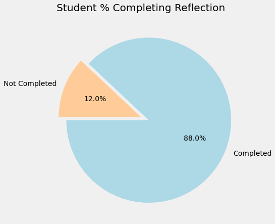

```python
# number of students who completed reflection

completed = len(reflections_df)
not_complete = len(students_df) - completed

# how many students in each tutorial section
plt.figure(figsize=(7,7))
plt.title("Student % Completing Reflection")

values = [completed, not_complete]
name = ["Completed", "Not Completed"]

colors = ['#ADD8E6','#ffcc99','#98AFC7','#ff9999','#d7edb9','#c4bcc0','#67805c','#ab446c','#41734f','#eb4034']
explode = (0.1, 0)

plt.pie(values, labels=name, colors=colors, startangle=-180,autopct='%1.1f%%',explode=explode)
plt.show()
```

# 1. Student Attendence During Current Week

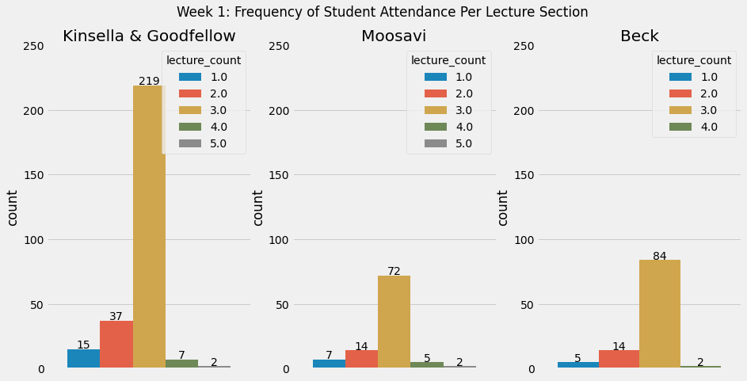

```python
fig, axs = plt.subplots(1, 3, figsize=(14, 7))

fig.suptitle("Week {}: Frequency of Student Attendance Per Lecture Section".format(week))

column_list = ["LEC0101_attended","LEC0102_attended","LEC0103_attended"]
lecture_list = [ x.split('_')[0] for x in column_list]

lecture_name = {
    "LEC0101": "Kinsella & Goodfellow",
    "LEC0102": "Moosavi",
    "LEC0103": "Beck"
}

for index, value in enumerate(column_list):
    data = combined_df[combined_df[value]==lecture_list[index]]
    sns.countplot(x=value, hue="lecture_count", data=data, ax=axs[index])
    axs[index].get_xaxis().set_visible(False)
    axs[index].set_ylim(0,250)
    axs[index].set_title(lecture_name[lecture_list[index]])

    # values=data['lecture_count'].value_counts().values
    # values = values[::-1]

    for i, p in enumerate(axs[index].patches):
        axs[index].annotate(f'{int(p.get_height())}',
                    (p.get_x() + p.get_width() / 2., p.get_height()),
                    ha = 'center', va = 'center',
                    xytext = (0, 5),
                    textcoords = 'offset points')


plt.show()
```

```python
combined_df['test'] = combined_df['lecture_sections'].str.contains('Lecture 1')
combined_df.head()
```

|  | section | section_id | section_sis_id | submitted | lecture_sections | lecture_reasons | lecture_alternate_section | hybrid_learning | video_materials | practice_problems | ... | Practical | discipline | LEC0101_attended | LEC0102_attended | LEC0103_attended | lecture_assigned | cleaned_answer | polarity | lecture_count | test |
| --- | --- | --- | --- | --- | --- | --- | --- | --- | --- | --- | --- | --- | --- | --- | --- | --- | --- | --- | --- | --- | --- |
| 0 | APS106H1-S-TUT0107-20241, APS106H1-S-LEC0103-2... | 320323, 320149, 320262 | APS106H1-S-TUT0107-20241, APS106H1-S-LEC0103-2... | 2024-01-15 06:00:00 UTC | Beck (LEC0103) - Lecture 1 (Monday\, 3 - 4 pm)... | I was studying for a term test for this course | Other | Coding along with the instructor on my device | LEC0102 - Moosavi Lecture Recording,LEC0103 - ... | No | ... | PRA0107 | Industrial | False | False | LEC0103 | True | good | 1.9 | 3.0 | True |
| 1 | APS106H1-S-PRA0102-20241, APS106H1-S-LEC0101-2... | 320224, 320111, 320285 | APS106H1-S-PRA0102-20241, APS106H1-S-LEC0101-2... | 2024-01-15 05:57:08 UTC | Kinsella & Goodfellow (LEC0101) - Lecture 2 (T... | The lectures are not an effective learning too... | NaN | Following the lecture by looking at the conten... | LEC0101 - Kinsella & Goodfellow Lecture Recording | No | ... | PRA0102 | Chemical | LEC0101 | False | False | True | nan | 0.0 | 2.0 | False |
| 2 | APS106H1-S-PRA0103-20241, APS106H1-S-TUT0108-2... | 320231, 320328, 320111 | APS106H1-S-PRA0103-20241, APS106H1-S-TUT0108-2... | 2024-01-15 05:55:41 UTC | Kinsella & Goodfellow (LEC0101) - Lecture 1 (T... | NaN | NaN | Following the lecture by looking at the conten... | NaN | No | ... | PRA0103 | Mechanical | LEC0101 | False | False | True | excited | 1.4 | 3.0 | True |
| 3 | APS106H1-S-LEC0101-20241, APS106H1-S-TUT0103-2... | 320111, 320294, 320270 | APS106H1-S-LEC0101-20241, APS106H1-S-TUT0103-2... | 2024-01-15 05:50:50 UTC | Kinsella & Goodfellow (LEC0101) - Lecture 1 (T... | NaN | NaN | Following the lecture by looking at the conten... | LEC0101 - Kinsella & Goodfellow Lecture Recording | No | ... | NaN | NaN | LEC0101 | False | False | False | i feel that is a course that will start becomi... | 0.3 | 3.0 | True |
| 4 | APS106H1-S-LEC0103-20241, APS106H1-S-TUT0108-2... | 320149, 320328, 320270 | APS106H1-S-LEC0103-20241, APS106H1-S-TUT0108-2... | 2024-01-15 05:29:00 UTC | Beck (LEC0103) - Lecture 1 (Monday\, 3 - 4 pm)... | NaN | NaN | Following the lecture by looking at the conten... | NaN | No | ... | PRA0108 | Materials | False | False | LEC0103 | True | competent | 1.3 | 3.0 | True |

5 rows × 33 columns

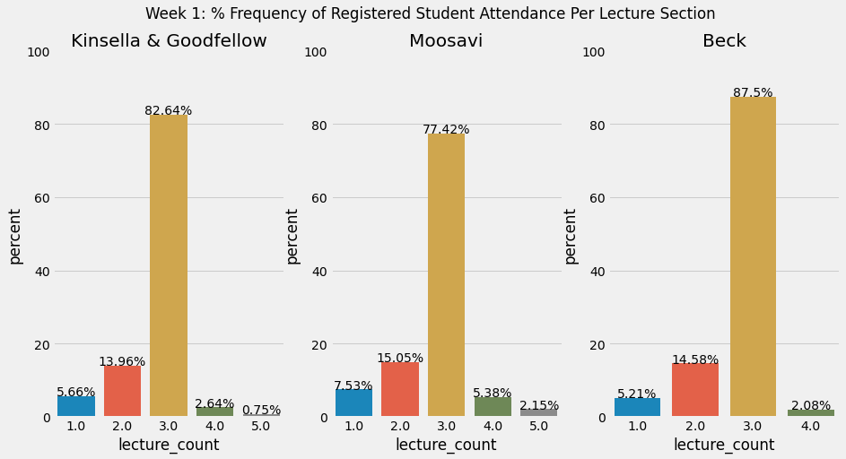

```python
fig, axs = plt.subplots(1, 3, figsize=(14, 7))

fig.suptitle("Week {}: % Frequency of Registered Student Attendance Per Lecture Section ".format(week))

column_list = ["LEC0101_attended","LEC0102_attended","LEC0103_attended"]
lecture_list = [ x.split('_')[0] for x in column_list]

lecture_name = {
    "LEC0101": "Kinsella & Goodfellow",
    "LEC0102": "Moosavi",
    "LEC0103": "Beck"
}

assigned_lecture = [
    len(combined_df[combined_df["Lecture"]=="LEC0101"]),
    len(combined_df[combined_df["Lecture"]=="LEC0102"]),
    len(combined_df[combined_df["Lecture"]=="LEC0103"])
]

for index, value in enumerate(column_list):

    #filter down the dataframe only to the specific lecturer
    df_temp = combined_df[combined_df[value]==lecture_list[index]]
    df_temp = df_temp.groupby("lecture_count").agg('count')

    df_temp =  df_temp[["section"]].copy().reset_index()
    df_temp['percent'] = df_temp['section'] / assigned_lecture[index] * 100


    sns.barplot(data=df_temp, x="lecture_count", y="percent", ax=axs[index])
    axs[index].set_ylim(0,100)
    axs[index].set_title(lecture_name[lecture_list[index]])

    values = list(df_temp['percent'])

    for i, p in enumerate(axs[index].patches):
        height = p.get_height()
        axs[index].text(p.get_x()+p.get_width()/2., height + 0.1,"{}%".format(round((values[i]),2)),ha="center")

plt.show()
```

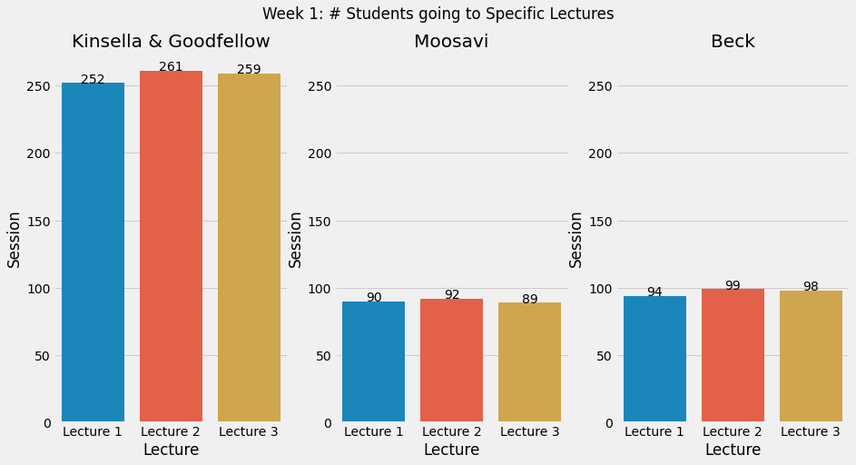

```python
# figure out which specific sections students are going to
fig, axs = plt.subplots(1, 3, figsize=(14, 7))

fig.suptitle("Week {}: # Students going to Specific Lectures".format(week))

lecture = [
         'Lecture 1',
         'Lecture 2',
         'Lecture 3']

lectures = [
            'Kinsella & Goodfellow',
            'Moosavi',
            'Beck']

for index, lec in enumerate(lectures):

    session_count = []

    # define a count for each individual session
    for session in lecture:
        # print(session)
        count = combined_df['lecture_sections'].str.contains(session) & combined_df['lecture_sections'].str.contains(lectures[index])
        count = count.sum()
        # print(count)
        session_count.append(count)

    # convert list to dataframe
    df = pd.DataFrame({'Lecture': lecture,
                       'Session': session_count})

    # create the barplot
    sns.barplot(x='Lecture', y='Session', data=df, ax=axs[index])
    # axs[index].get_xaxis().set_visible(False)
    axs[index].set_ylim(0,275)
    axs[index].set_title(lecture_name[lecture_list[index]])

    values = list(df['Session'])

    for i, p in enumerate(axs[index].patches):
        height = p.get_height()
        axs[index].text(p.get_x()+p.get_width()/2., height + 0.1,"{}".format(round((values[i]),2)),ha="center")

plt.show()
```

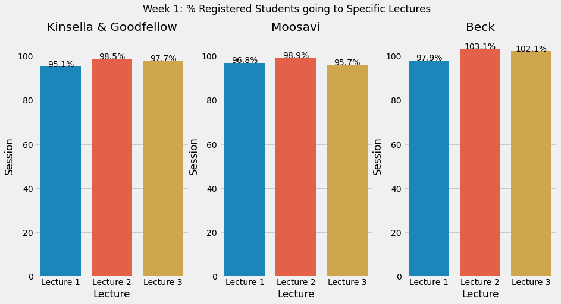

```python
# figure out which specific sections students are going to
fig, axs = plt.subplots(1, 3, figsize=(14, 7))

fig.suptitle("Week {}: % Registered Students going to Specific Lectures".format(week))

lecture = [
         'Lecture 1',
         'Lecture 2',
         'Lecture 3']

lectures = [
            'Kinsella & Goodfellow',
            'Moosavi',
            'Beck']

section = ['LEC0101','LEC0102','LEC0103']

# number students registered per section
combined_df = combined_df.sort_values(by='Lecture')

for index, lec in enumerate(lectures):

    session_count = []

    # define a count for each individual session
    for session in lecture:
        # print(session)
        count = combined_df['lecture_sections'].str.contains(session) & combined_df['lecture_sections'].str.contains(lectures[index])
        count = count.sum()
        session_count.append(count)

    # total number students registered in section
    registered = combined_df['Lecture'].str.contains(section[index]).sum()

    # update session count to be a percent
    session_count = [x/registered*100 for x in session_count]

    # convert list to dataframe
    df = pd.DataFrame({'Lecture': lecture,
                       'Session': session_count})

    # create the barplot
    sns.barplot(x='Lecture', y='Session', data=df, ax=axs[index])
    axs[index].set_ylim(0,110)
    axs[index].set_title(lecture_name[lecture_list[index]])

    values = list(df['Session'])

    for i, p in enumerate(axs[index].patches):
        height = p.get_height()
        axs[index].text(p.get_x()+p.get_width()/2., height + 0.1,"{}%".format(round((values[i]),1)),ha="center")

plt.show()
```

[output not shown]

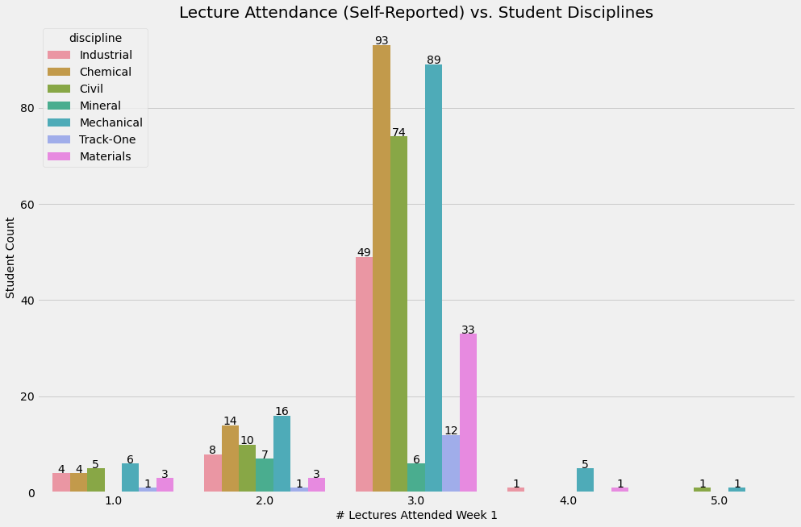

```python
plt.figure(figsize=(15,10))
plt.title('Lecture Attendance (Self-Reported) vs. Student Disciplines', fontsize = 20)
ax = sns.countplot(x="lecture_count", hue="discipline", data=combined_df[combined_df['lecture_count']!=0])

# for container in ax.containers:
#     ax.bar_label(container)

for i, p in enumerate(ax.patches):
    height = p.get_height()
    ax.text(p.get_x()+p.get_width()/2., height + 0.1,"{}".format(str(p).split(',')[3].split('=')[1]),ha="center")

ax.set_ylabel('Student Count', fontsize=14)
ax.set_xlabel('# Lectures Attended Week 1', fontsize=14)
plt.show()
```

One note: these percentages are based on the students who **answered the survey!**

[output not shown]

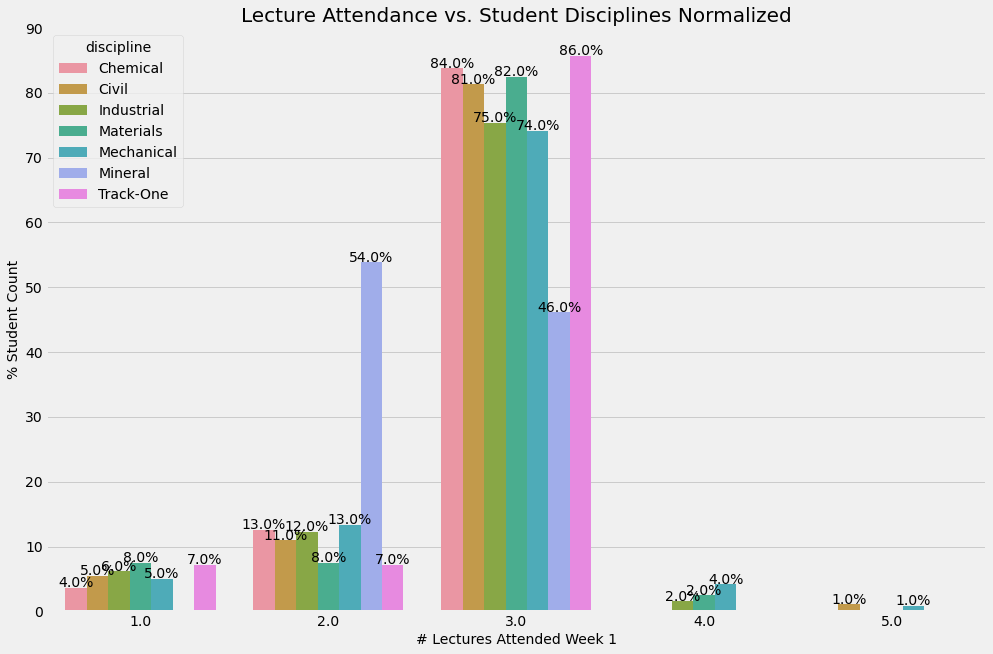

```python
#define the total counts per discipline
total_students = dict(combined_df['discipline'].value_counts())

#define separate dataframe based on student discipline + attendance counts
agg_students = combined_df.groupby(['discipline','lecture_count']).count()
agg_students = agg_students.reset_index()
agg_students =  agg_students[["discipline","lecture_count","section"]].copy()
#agg_students = agg_students[agg_students['lecture_count']!=0]

agg_students['total_count'] = agg_students['discipline'].map(total_students)
agg_students['percent'] = agg_students['section'] / agg_students['total_count'] * 100

plt.figure(figsize=(15,10))
plt.title('Lecture Attendance vs. Student Disciplines Normalized', fontsize = 20)
ax = sns.barplot(x="lecture_count", y="percent", hue="discipline", data=agg_students)

# add labels
for i, p in enumerate(ax.patches):
    height = p.get_height()
    ax.text(p.get_x()+p.get_width()/2., height + 0.1,"{}%".format(round(height,0)),ha="center")

ax.set_ylabel('% Student Count', fontsize=14)
ax.set_xlabel('# Lectures Attended Week 1', fontsize=14)

plt.show()
```

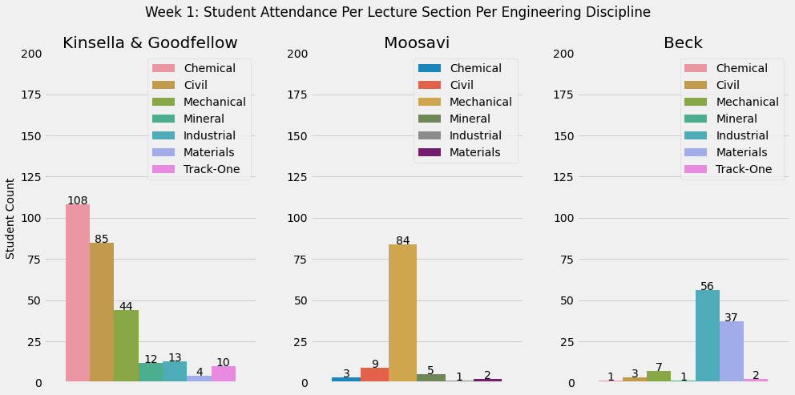

```python
fig, axs = plt.subplots(1, 3, figsize=(14, 7))

fig.suptitle("Week 1: Student Attendance Per Lecture Section Per Engineering Discipline")

column_list = ["LEC0101_attended","LEC0102_attended","LEC0103_attended"]
lecture_list = [ x.split('_')[0] for x in column_list]

lecture_name = {
    "LEC0101": "Kinsella & Goodfellow",
    "LEC0102": "Moosavi",
    "LEC0103": "Beck"
}

# convert discipline columns to numeric (so consistent between lecture sections)
disciplines_num = {
    "Chemical":1,
    "Civil":2,
    "Mechanical":3,
    "Mineral":4,
    "Industrial":5,
    "Materials":6,
    "Track-One":7,
    "Non-Degree":8
    }

combined_df['discipline_num'] = combined_df['discipline'].map(disciplines_num)

for index, value in enumerate(column_list):
    sns.countplot(x=value, hue="discipline_num", data=combined_df[combined_df[value]==lecture_list[index]], ax=axs[index])
    axs[index].get_xaxis().set_visible(False)
    axs[index].set_ylim(0,200)
    axs[index].set_title(lecture_name[lecture_list[index]])
    axs[index].legend(labels = list(disciplines_num.keys()))

    for i, p in enumerate(axs[index].patches):
        height = p.get_height()
        axs[index].text(p.get_x()+p.get_width()/2., height + 0.1,"{}".format(str(p).split(',')[3].split('=')[1][0:4]),ha="center")

    if index == 0:
        axs[index].set_ylabel('Student Count', fontsize=14)
    else:
        axs[index].set_ylabel(' ')

# Rotating x-axis labels for each subplot
for ax in axs:
    ax.set_xticklabels(ax.get_xticklabels(), rotation=45, ha='right')

fig.tight_layout()
plt.show()
```

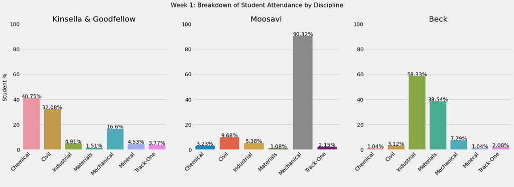

```python
fig, axs = plt.subplots(1, 3, figsize=(19, 7))

fig.suptitle("Week 1: Breakdown of Student Attendance by Discipline", size =16)

column_list = ["LEC0101_attended","LEC0102_attended","LEC0103_attended"]
lecture_list = [ x.split('_')[0] for x in column_list]

lecture_name = {
    "LEC0101": "Kinsella & Goodfellow",
    "LEC0102": "Moosavi",
    "LEC0103": "Beck"
}

assigned_lecture = [
    len(combined_df[combined_df["Lecture"]=="LEC0101"]),
    len(combined_df[combined_df["Lecture"]=="LEC0102"]),
    len(combined_df[combined_df["Lecture"]=="LEC0103"])
]

for index, value in enumerate(column_list):

    #filter down the dataframe only to the specific lecturer
    df_temp = combined_df[combined_df[value]==lecture_list[index]]
    df_temp = df_temp.groupby("discipline").agg('count')

    df_temp =  df_temp[["section"]].copy().reset_index()
    df_temp['percent'] = df_temp['section'] / assigned_lecture[index] * 100


    sns.barplot(data=df_temp, x="discipline", y="percent", ax=axs[index])
    axs[index].set_ylim(0,100)
    axs[index].set_title(lecture_name[lecture_list[index]])

    # Rotate the labels on the x-axis to 45 degrees
    # plt.xticks(rotation=45)

    values = list(df_temp['percent'])

    for i, p in enumerate(axs[index].patches):
        height = p.get_height()
        axs[index].text(p.get_x()+p.get_width()/2., height + 0.1,"{}%".format(round((values[i]),2)),ha="center")

    axs[index].set_xlabel(' ')
    if index == 0:
        axs[index].set_ylabel('Student %', fontsize=14)
    else:
        axs[index].set_ylabel(' ')

# Rotating x-axis labels for each subplot
for ax in axs:
    ax.set_xticklabels(ax.get_xticklabels(), rotation=45, ha='right')

fig.tight_layout()
plt.show()
```

```python
q2_values.values()
```

```
dict_values(['Other', 'Lectures Not Effective', 'APS106 Term Test', 'Another Class Term Test', 'APS106 Assignments', 'Another Class Assignments', 'Lecture Timing', 'Lecture Room Issue'])
```

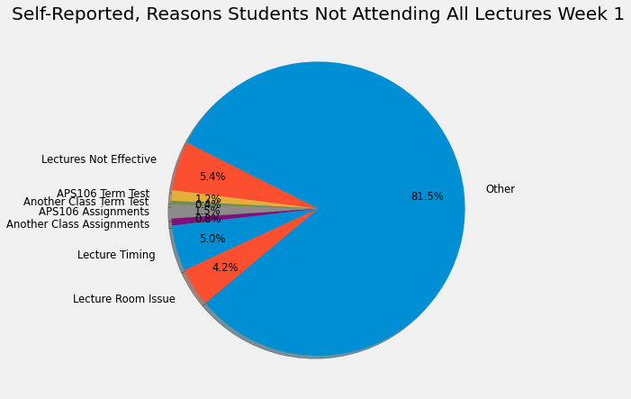

```python
# reason students not going to assigned lecture section
# combined_df['lecture_reasons'].unique()

q2_values = {
    'Other':'Other',
    'The lectures are not an effective learning tool for me':'Lectures Not Effective',
    'I was studying for a term test for this course':'APS106 Term Test',
    'I was studying for a term test for another course':'Another Class Term Test',
    'I was working on assignments for this course':'APS106 Assignments',
    'I was working on assignments and/or projects for another course':'Another Class Assignments',
    'The lecture times make them challenging to regularly attend':'Lecture Timing',
    'The lecture room is not conducive to learning':'Lecture Room Issue'
}

q2_counts = []

for key, value in q2_values.items():
    count = combined_df['lecture_reasons'].str.contains(key)
    count = count.sum()
    q2_counts.append(count)


plt.figure(figsize=(7,7))
plt.title("Self-Reported, Reasons Students Not Attending All Lectures Week {}".format(week))

plt.pie(q2_counts, labels=q2_values.values(), startangle=-140,autopct='%1.1f%%', shadow=True, pctdistance=0.75, labeldistance=1.15)

# Change the fontsize of the labels and percentages
plt.setp(plt.gca().texts, fontsize='small')  # Pie chart labels and percentages font size


plt.show()
```

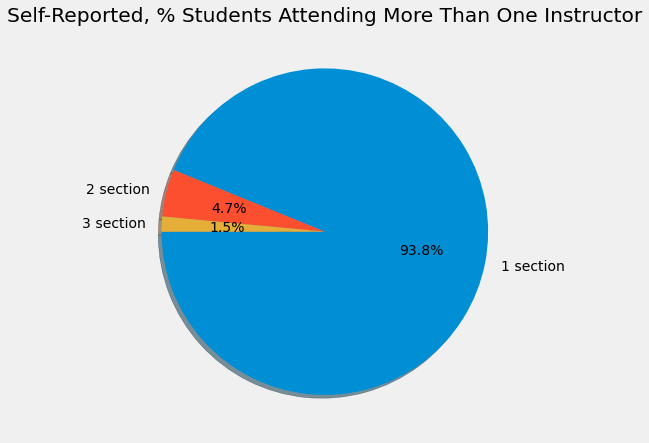

```python
# how many students attended more than one instructor session last week (i.e. both Kinsella and Beck lectures)
plt.figure(figsize=(7,7))
plt.title("Self-Reported, % Students Attending More Than One Instructor")

# combined_df['multiple_sections'] = combined_df['lecture_sections'].str.contains(",")
combined_df['multiple_sections'] = combined_df[['LEC0101_attended', 'LEC0102_attended',
                                                'LEC0103_attended']].applymap(lambda x: isinstance(x, str) and x != 'False').sum(axis=1)


combined_df = combined_df.sort_values(by='multiple_sections')
name = ["{} section".format(x) for x in combined_df['multiple_sections'].value_counts().keys()]
values = combined_df['multiple_sections'].value_counts()
# values = values[::-1]

# colors = ['#ADD8E6','#ffcc99','#98AFC7','#ff9999','#ffcc99']
# explode = (0.2, 0)

plt.pie(values, labels=name, startangle=-180,autopct='%1.1f%%', shadow=True)
plt.show()
```

```
posx and posy should be finite values
posx and posy should be finite values
posx and posy should be finite values
posx and posy should be finite values
```

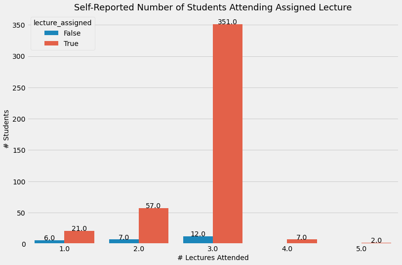

```python
# how many students are not attending their assigned lecture section?
plt.figure(figsize=(12,8))

plt.title('Self-Reported Number of Students Attending Assigned Lecture', fontsize = 18)
ax = sns.countplot(x="lecture_count", hue="lecture_assigned", data=combined_df[combined_df['lecture_count']>0])

for i, p in enumerate(ax.patches):
    height = p.get_height()
    ax.text(p.get_x()+p.get_width()/2., height + 0.1, height ,ha="center")

ax.set_xlabel('# Lectures Attended', fontsize=14)
ax.set_ylabel('# Students', fontsize=14)

plt.show()
```

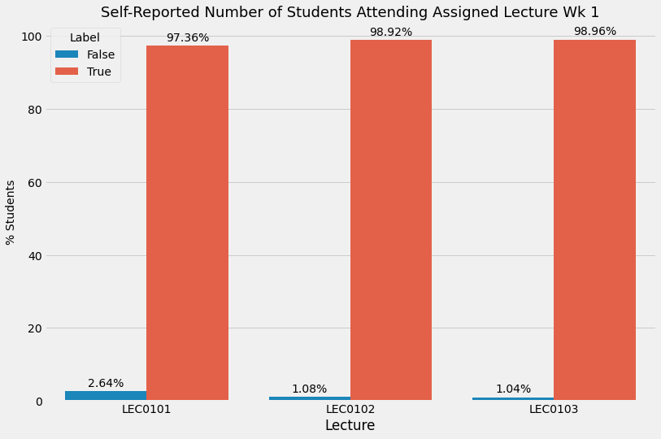

```python
# how many students are not attending their assigned lecture section?
plt.figure(figsize=(12,8))

lecture_name = {
    "LEC0101": "Kinsella & Goodfellow",
    "LEC0102": "Moosavi",
    "LEC0103": "Beck"
}

plt.title('Self-Reported Number of Students Attending Assigned Lecture Wk {}'.format(week), fontsize = 18)
combined_df['lecture_name_assigned'] = combined_df['Lecture'].map(lecture_name)

lectures = []
counts = []
labels = []

# need to loop through each lecture, generate a new dataframe
for lecture in lecture_name:
    temp_df = combined_df[combined_df['Lecture']==lecture]
    total = len(temp_df)
    counts.append(len(temp_df[temp_df['lecture_assigned']==True]) / total*100)
    counts.append(len(temp_df[temp_df['lecture_assigned']==False]) / total*100)
    labels.append(True)
    labels.append(False)
    lectures.append(lecture)
    lectures.append(lecture)


lecture_df = pd.DataFrame({'Lecture':lectures,'Assigned Lecture':counts,'Label':labels})

ax = sns.barplot(x="Lecture", y = 'Assigned Lecture', hue="Label", data=lecture_df)

# ax.set_xlabel('Total Students Present per Lecture Section', fontsize=14)
ax.set_ylabel('% Students', fontsize=14)

# Annotate each bar with its value, rounded to two decimal places
for p in ax.patches:
    ax.annotate(f"{p.get_height():.2f}%",
                (p.get_x() + p.get_width() / 2., p.get_height()),
                ha = 'center', va = 'center',
                xytext = (0, 10),
                textcoords = 'offset points')

plt.show()
```

To interpret plot above, the number of students present can be found by summing assigned + not assigned students. For example, Beck's lecture had 1 + 95 = 96 unique students attending last week.

```python
combined_df.columns
```

```
Index(['section', 'section_id', 'section_sis_id', 'submitted',
       'lecture_sections', 'lecture_reasons', 'lecture_alternate_section',
       'hybrid_learning', 'video_materials', 'practice_problems',
       'progress_check', 'comment_one_word', 'confused_topics', 'previous_exp',
       'aps106_future_use', 'coding_future', 'python_setup', 'languages',
       'variable_check', 'expression_check', 'operator_check', 'Lecture',
       'Tutorial', 'Practical', 'discipline', 'LEC0101_attended',
       'LEC0102_attended', 'LEC0103_attended', 'lecture_assigned',
       'cleaned_answer', 'polarity', 'lecture_count', 'test', 'discipline_num',
       'multiple_sections', 'lecture_name_assigned'],
      dtype='object')
```

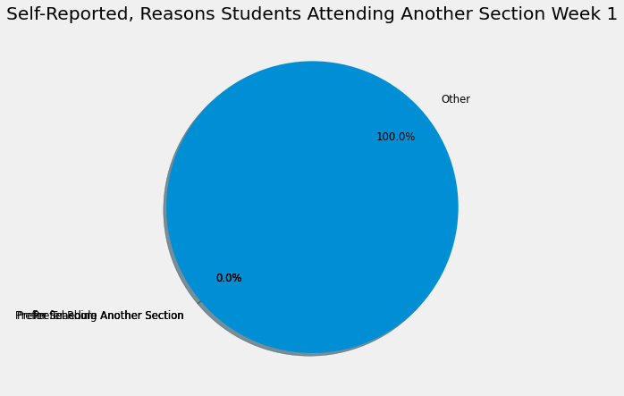

```python
# reasons students not going to assigned lecture
q3_values = {
    'Other':'Other',
    'I prefer the teaching style in another section(s)': 'Prefer Teaching Another Section',
    'I prefer the scheduling of the lectures in another section(s)': 'Prefer Schedule Another Section',
    'I prefer the room of the lectures in another section(s)': 'Prefer Room Another Section'
}

q3_counts = []

for key, value in q3_values.items():
    count = combined_df['lecture_alternate_section'].str.contains(key)
    count = count.sum()
    q3_counts.append(count)


plt.figure(figsize=(7,7))
plt.title("Self-Reported, Reasons Students Attending Another Section Week {}".format(week))

plt.pie(q3_counts, labels=q3_values.values(), startangle=-140,autopct='%1.1f%%', shadow=True, pctdistance=0.75, labeldistance=1.15)

# Change the fontsize of the labels and percentages
plt.setp(plt.gca().texts, fontsize='small')  # Pie chart labels and percentages font size


plt.show()
```

# Student Comfort Level with Coding

```python
combined_df['previous_exp'].unique()
```

```
array(['I can write some code but just the basics',
       'I can write code at an intermediate level',
       'I have never written a single line of computer code',
       'I consider myself an advanced coder', nan], dtype=object)
```

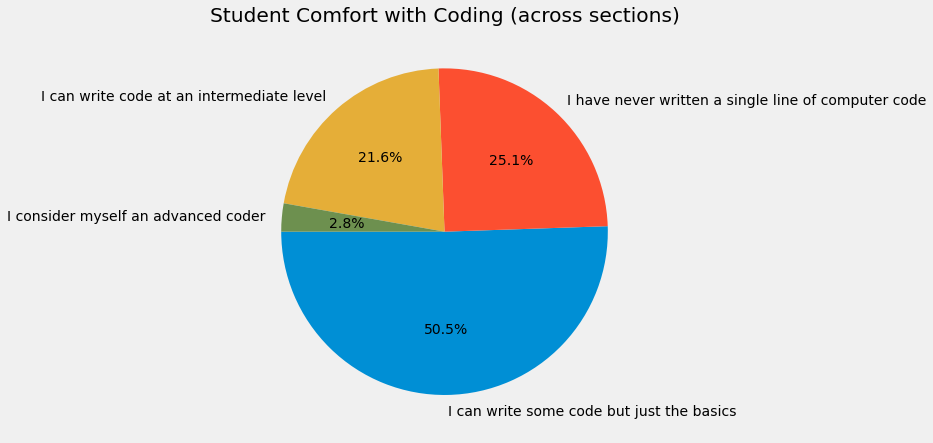

```python
# how many students in each tutorial section
plt.figure(figsize=(7,7))
plt.title("Student Comfort with Coding (across sections)")

name = list(dict(combined_df.previous_exp.value_counts()).keys())
values = list(dict(combined_df.previous_exp.value_counts()).values())

# colors = ['#ADD8E6','#98AFC7', '#ffcc99','#67805c','#ff9999','#d7edb9','#c4bcc0','#ab446c','#41734f','#eb4034']
explode = (0, 0, 0,0)

plt.pie(values, labels=name,  startangle=-180,autopct='%1.1f%%',explode=explode)
plt.show()
```

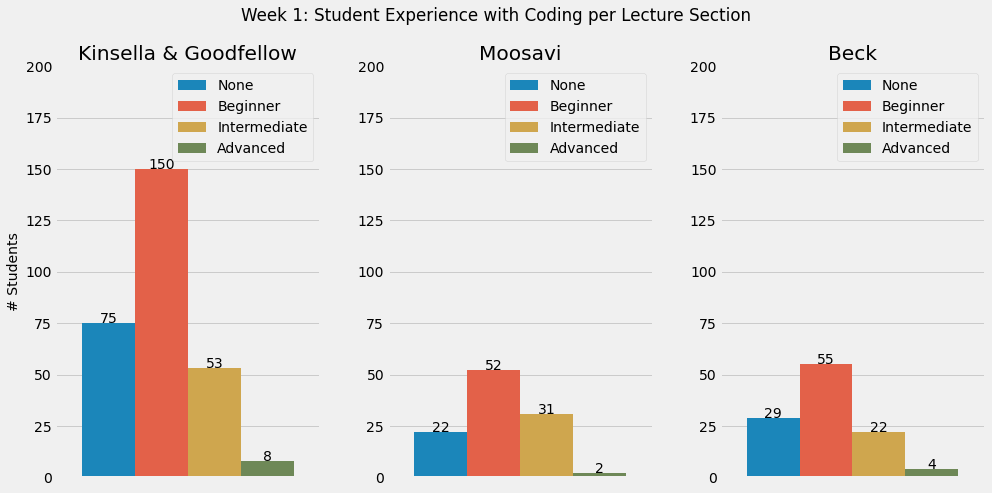

```python
fig, axs = plt.subplots(1, 3, figsize=(14, 7))

fig.suptitle("Week 1: Student Experience with Coding per Lecture Section")

column_list = ["LEC0101_attended","LEC0102_attended","LEC0103_attended"]
lecture_list = [ x.split('_')[0] for x in column_list]

lecture_name = {
    "LEC0101": "Kinsella & Goodfellow",
    "LEC0102": "Moosavi",
    "LEC0103": "Beck"
}

# convert discipline columns to numeric (so consistent between lecture sections)
exp_num = {
    'I have never written a single line of computer code': 0,
    'I can write some code but just the basics': 1,
    'I can write code at an intermediate level': 2,
    'I consider myself an advanced coder': 3
    }


labels = ["None", "Beginner", "Intermediate", "Advanced"]

combined_df['Experience'] = combined_df['previous_exp'].map(exp_num)

for index, value in enumerate(column_list):
    sns.countplot(x=value, hue="Experience", data=combined_df[combined_df[value]==lecture_list[index]], ax=axs[index])
    axs[index].get_xaxis().set_visible(False)
    axs[index].set_ylim(0,200)
    axs[index].set_title(lecture_name[lecture_list[index]])
    axs[index].legend(labels=labels)

    if index == 0:
        axs[index].set_ylabel('# Students', fontsize = 14)
    else:
        axs[index].set_ylabel(' ')

    for i, p in enumerate(axs[index].patches):
        height = p.get_height()
        axs[index].text(p.get_x()+p.get_width()/2., height + 0.1, height ,ha="center")

fig.tight_layout()
plt.show()
```

[output not shown]

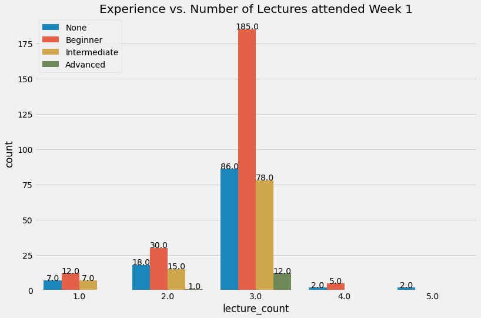

```python
# comfort level correlated with attendance level
plt.figure(figsize=(12,8))
ax = sns.countplot(x="lecture_count", hue="Experience", data=combined_df[combined_df["lecture_count"]>0])

for i, p in enumerate(ax.patches):
    height = p.get_height()
    ax.text(p.get_x()+p.get_width()/2., height + 0.1, height ,ha="center")

plt.legend(labels=labels)
plt.title('Experience vs. Number of Lectures attended Week 1')
plt.show()
```

```
posx and posy should be finite values
posx and posy should be finite values
posx and posy should be finite values
posx and posy should be finite values
```

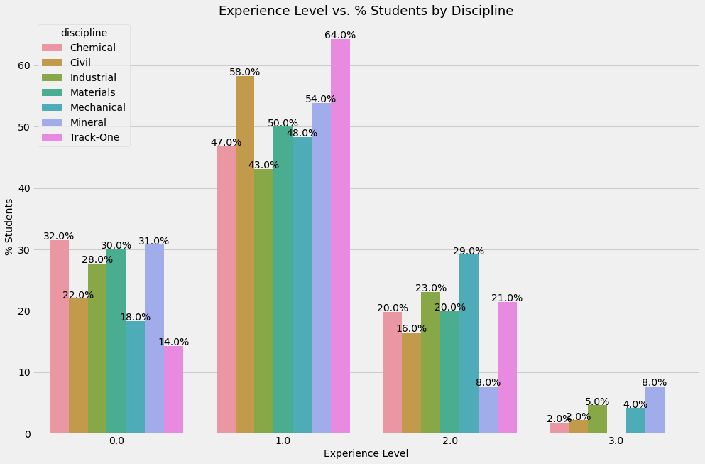

```python
# show student experience vs disciple
total_students = dict(combined_df['discipline'].value_counts())

#define separate dataframe based on student discipline + attendance counts
agg_students = combined_df.groupby(['discipline','Experience']).count()
agg_students = agg_students.reset_index()
agg_students =  agg_students[["discipline","Experience","section"]].copy()

agg_students['total_count'] = agg_students['discipline'].map(total_students)
agg_students['percent'] = agg_students['section'] / agg_students['total_count'] * 100

plt.figure(figsize=(15,10))
plt.title('Experience Level vs. % Students by Discipline', fontsize = 18)

agg_students.sort_values(by=['Experience'], key=lambda x: x.map(total_students),ascending=False)

ax = sns.barplot(x="Experience", y="percent", hue="discipline", data=agg_students)

for i, p in enumerate(ax.patches):
    height = p.get_height()
    ax.text(p.get_x()+p.get_width()/2., height + 0.1, "{}%".format(round(height,0)) ,ha="center")

ax.set_ylabel('% Students', fontsize=14)
ax.set_xlabel('Experience Level', fontsize=14)

plt.show()
```

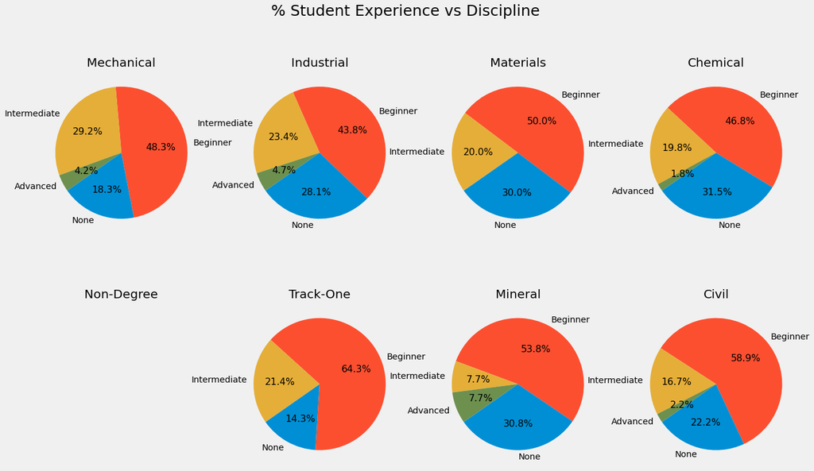

```python
# looking at experience levels of students per discipline (self-identified in week 1 reflection)

# define disciplines
disciplines = [
    'Mechanical',
    'Industrial',
    'Materials',
    'Chemical',
    'Non-Degree',
    'Track-One',
    'Mineral',
    'Civil'
]

# loop through disciplines, generate pie chart of experience across students

titles = [discipline for discipline in disciplines]
fig, axs = plt.subplots(2, 4, figsize=(20, 12))

fig.suptitle("% Student Experience vs Discipline", fontsize = 25)

row = 0
col = 0

sns.set_context("notebook", font_scale=1.3, rc={"lines.linewidth": 3})

exp_num = {
    "None": 0,
    "Beginner": 1,
    "Intermediate": 2,
    "Advanced": 3
    }

exp_label = {
    'I have never written a single line of computer code': 'None',
    'I can write some code but just the basics': 'Beginner',
    'I can write code at an intermediate level': 'Intermediate',
    'I consider myself an advanced coder': 'Advanced'
    }

combined_df['Experience_Label'] = combined_df['previous_exp'].map(exp_label)

for index, discipline in enumerate(disciplines):

    # filter the dataframe
    df_filt = combined_df[combined_df['discipline']==discipline]

    df_grouped = df_filt.groupby('Experience_Label').agg('count')
    df_grouped = df_grouped.reset_index()
    df_grouped['exp_num'] = df_grouped['Experience_Label'].map(exp_num)
    df_grouped = df_grouped.sort_values(by=['exp_num'])

    values = df_grouped['section'].to_list()
    labels = df_grouped['Experience_Label'].to_list()

    axs[row,col].pie(values, labels=labels, autopct='%1.1f%%', startangle=215,)
    axs[row,col].title.set_text("{}".format(titles[index]))

    if (index + 1) % 4 == 0:
        row += 1
        col = 0
    else:
        col += 1

plt.show()
```

```python
combined_df['coding_future'].value_counts().keys()
```

```
Index(['Yes', 'Not sure', 'No'], dtype='object', name='coding_future')
```

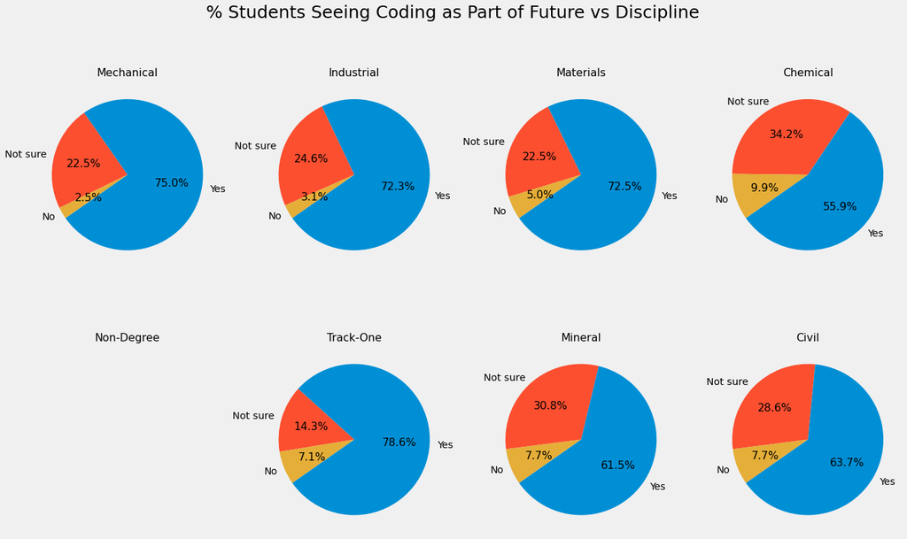

```python
# looking at students per discipline, how many see coding as part of their future

# define disciplines
disciplines = [
    'Mechanical',
    'Industrial',
    'Materials',
    'Chemical',
    'Non-Degree',
    'Track-One',
    'Mineral',
    'Civil'
]

# loop through disciplines, generate pie chart of experience across students

titles = [discipline for discipline in disciplines]
fig, axs = plt.subplots(2, 4, figsize=(20, 12))

fig.suptitle("% Students Seeing Coding as Part of Future vs Discipline", fontsize = 25)

row = 0
col = 0

sns.set_context("notebook", font_scale=1.3, rc={"lines.linewidth": 3})

combined_df['coding_future'] = combined_df['coding_future'].fillna('Not sure')
combined_df['coding_future'] = combined_df['coding_future'].replace(0, 'Not sure')

for index, discipline in enumerate(disciplines):

    # filter the dataframe
    df_filt = combined_df[combined_df['discipline']==discipline]

    values = dict(df_filt['coding_future'].value_counts()).values()
    labels = dict(df_filt['coding_future'].value_counts()).keys()

    axs[row,col].pie(values, labels=labels, autopct='%1.1f%%', startangle=215,)
    axs[row,col].title.set_text("{}".format(titles[index]))

    if (index + 1) % 4 == 0:
        row += 1
        col = 0
    else:
        col += 1

plt.show()
```

```python
# similar for how many will reach for APS106 in the future
```

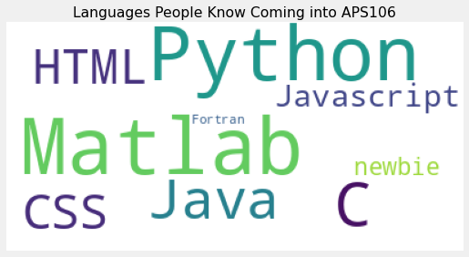

```python
# show student experience versus languages people have experience in, for each lecture section

# will do this as a word cloud
from wordcloud import WordCloud
from wordcloud import ImageColorGenerator
from wordcloud import STOPWORDS

#a word cloud is generated to show the most frequently appearing words
word_text = str((combined_df['languages'].values))
word_text = word_text.replace("'","")
word_text = word_text.replace("nan", "newbie") #TODO:: ask about this

# define word cloud
stopwords = set(STOPWORDS)
languages = WordCloud(stopwords=stopwords, background_color="white", collocations=False).generate(word_text)
plt.figure(figsize=(8,8))
plt.imshow(languages)
plt.axis("off")
plt.title("Languages People Know Coming into APS106")

plt.show()
```

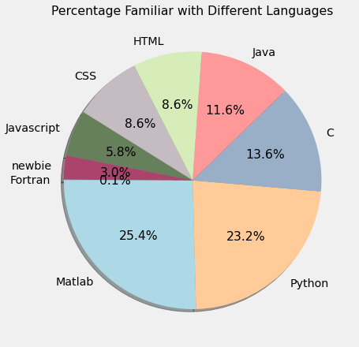

```python
# how many students attended more than one instructor session last week (i.e. both Kinsella and Rosu lectures)
plt.figure(figsize=(7,7))
plt.title("Percentage Familiar with Different Languages")

name = list(dict(languages.words_).keys())
values = list(dict(languages.words_).values())

colors = ['#ADD8E6','#ffcc99','#98AFC7','#ff9999','#d7edb9','#c4bcc0','#67805c','#ab446c']
# explode = (0, 0.2, 0,0,0,0,0,0)

plt.pie(values, labels=name, colors=colors, startangle=-180,autopct='%1.1f%%', shadow=True)
plt.show()
```

# Individual Topics Covered During the Week

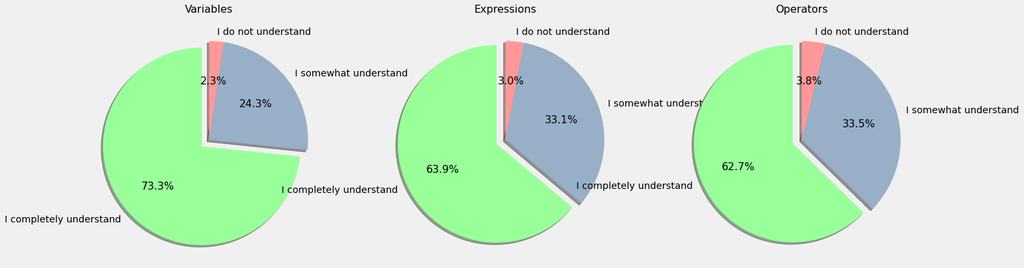

```python
# check general % of students comfortable with the new topics

columns = ['variable_check', 'expression_check', 'operator_check']
fig, ax = plt.subplots(1,len(columns), figsize=(20, 20))


for index, value in enumerate(columns):
    column = dict(combined_df[value].value_counts())
    data = list(column.values())
    labels = list(column.keys())

    explode = (0.1, 0, 0)

    total = sum(data)
    data_per = data/total*100

    colors = ['#99ff99','#98AFC7','#ff9999','#ffcc99']

    #ax[index].pie(data_per, labels = [round(i,2) for i in (list(data_per))])

    ax[index].pie(data_per, labels = labels, colors = colors, autopct='%1.1f%%', shadow=True, startangle=90,explode=explode)
    ax[index].title.set_text("{}s".format(str(columns[index]).split("_")[0].capitalize()))


plt.show()
```

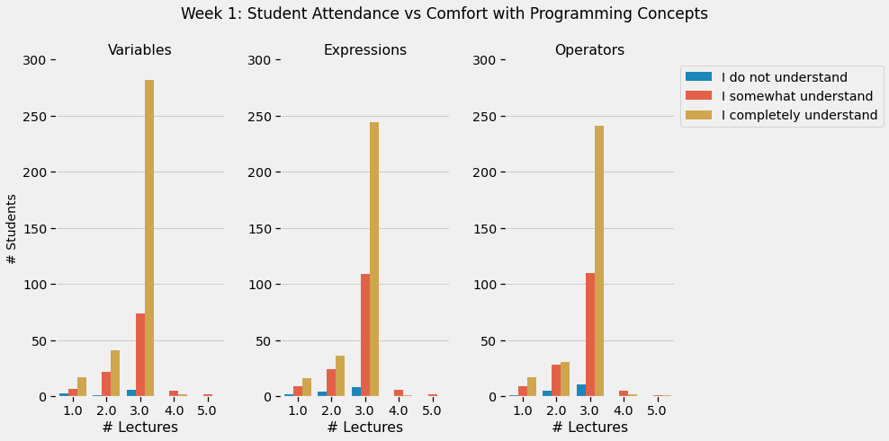

```python
# comfort level correlated with attendance level

fig, axs = plt.subplots(1, 3, figsize=(14, 7))

fig.suptitle("Week 1: Student Attendance vs Comfort with Programming Concepts", fontsize = 17)
columns = ['variable_check', 'expression_check', 'operator_check']

numeric = {
    'I do not understand': 0,
    'I somewhat understand': 1,
    'I completely understand': 2
}

new_column = [ x + '_numeric' for x in columns]

for index, value in enumerate(columns):

    combined_df[new_column[index]] = combined_df[value].map(numeric)

    sorted_df = combined_df.sort_values(by=[new_column[index]])
    sns.countplot(x="lecture_count", hue=value, data=sorted_df, ax=axs[index])
    axs[index].set_title("{}s".format(str(value.split("_")[0].capitalize())))

    # for i, p in enumerate(axs[index].patches):
    #     height = p.get_height()
    #     axs[index].text(p.get_x()+p.get_width()/2., height + 0.1, height ,ha="center")

    if index == 0:
        axs[index].set_ylabel("# Students", fontsize = 14)
    else:
        axs[index].set_ylabel(" ", fontsize = 6)

    axs[index].set_ylim(0,300)
    axs[index].set_xlabel('# Lectures')


# Remove legend from the first two plots and add it to the last plot
axs[0].get_legend().remove()
axs[1].get_legend().remove()
axs[2].legend(loc='upper left', bbox_to_anchor=(1, 1))

fig.tight_layout()
plt.show()
```

[output not shown]

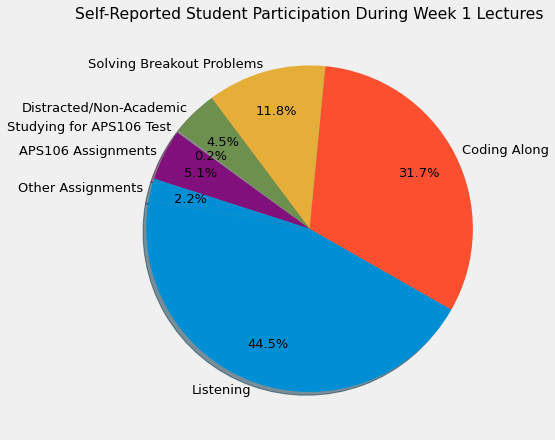

```python
# what did students do in lecture during the week

q4_values = [
    'Following the lecture by looking at the content and listening to the instructor',
    'Coding along with the instructor on my device',
    'Trying to solve the breakout problems',
    'Distracted with non-academic activities',
    'I was studying for a term test for this course',
    'I was studying for a term test for another course',
    'I was working on assignments for this course',
    'I was working on assignments and/or projects for another course'
]

q4_labels = [
    'Listening',
    'Coding Along',
    'Solving Breakout Problems',
    'Distracted/Non-Academic',
    'Studying for APS106 Test',
    'Studying for Other Test',
    'APS106 Assignments',
    'Other Assignments'
]

q4_counts = []

for value in q4_values:
    count = combined_df['hybrid_learning'].str.contains(value)
    count = count.sum()
    q4_counts.append(count)

for index, value in enumerate(q4_counts):
    if value == 0:
        q4_counts.remove(0)
        q4_values.pop(index)
        q4_labels.pop(index)

plt.figure(figsize=(7,7))
plt.title("Self-Reported Student Participation During Week {} Lectures".format(week))

plt.pie(q4_counts, labels=q4_labels, startangle=-190,autopct='%1.1f%%', shadow=True, pctdistance=0.75, labeldistance=1.05)

# Change the fontsize of the labels and percentages
plt.setp(plt.gca().texts, fontsize='small')  # Pie chart labels and percentages font size


plt.show()
```

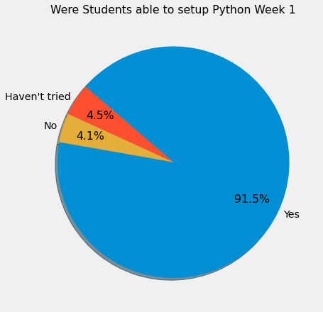

```python
# were students able to setup Python in week 1?

# are students feeling up to date or behind

plt.figure(figsize=(7,7))
plt.title("Were Students able to setup Python Week {}".format(week))

values = dict(combined_df['python_setup'].value_counts()).values()
labels = dict(combined_df['python_setup'].value_counts()).keys()

plt.pie(values, labels=labels, startangle=-190,autopct='%1.1f%%', shadow=True, pctdistance=0.75, labeldistance=1.05)

plt.show()
```

[figure not shown]

```python
# which video materials are people using per lecture section

fig, axs = plt.subplots(1, 3, figsize=(19, 7))

fig.suptitle("Week {}: Student Setup with Python by Section".format(week), size =16)

lecture_sections = ['LEC0101', 'LEC0102', 'LEC0103']

for index, lecture in enumerate(lecture_sections): # we will check against assigned lecture sections

    temp_df = combined_df[combined_df['Lecture']==lecture]

    values = dict(temp_df['python_setup'].value_counts()).values()
    labels = dict(temp_df['python_setup'].value_counts()).keys()

    axs[index].pie(values, labels = labels, autopct='%1.1f%%', shadow=True, startangle=45)
    axs[index].title.set_text("Online Material Use in {} Section".format(str(lecture_list[index])))

plt.show()
```

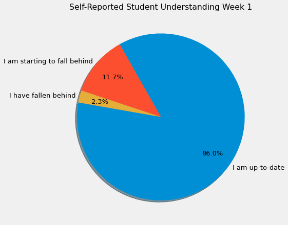

```python
# are students feeling up to date or behind

plt.figure(figsize=(7,7))
plt.title("Self-Reported Student Understanding Week {}".format(week))

values = dict(combined_df['progress_check'].value_counts()).values()
labels = dict(combined_df['progress_check'].value_counts()).keys()

plt.pie(values, labels=labels, startangle=-190,autopct='%1.1f%%', shadow=True, pctdistance=0.75, labeldistance=1.05)

# Change the fontsize of the labels and percentages
plt.setp(plt.gca().textxs, fontsize='small')  # Pie chart labels and percentages font size


plt.show()
```